# Домашнее задание 1.

May 24, 2018

Домашнее задание можно выполнять на данных с которымии вы работаете :) Если таких нет, то можно использовать данные про хлопья для завтрака `cereal.csv`.

Описание данных:

- Name - название производителя хлопьев
- mfr - название производителя
- type - тип хлопьев
- protein - белки, в гм на порцию
- fat - жиры в гм на порцию
- sodium - натрий в мг на порцию
- fiber - клетчатка в гм на порцию
- carbo - углеводы в гм на порцию
- sugars - сахар в гм на порцию
- potass - калий в мг на порцию
- vitamins - витамины и минералы
- shelf - полка, на которой хлопья стоят в магазине, считая от пола
- weight - вес одной порции в унциях
- cups - число чашек в порции
- rating - оценка хлопьев покупателями
1. Подключите библиотеки `tidyverse`, `rio`, `skimr`.

```r
library(tidyverse)
library(rio)
library(skimr)
```

2. Загрузите данные из файла `cereal.csv` (или из вашего файла) и сохраните их в переменной под названием `df`. Для этого нужно воспользоваться функцией `import` из пакета `rio`. Проверьте, что данные загрузились с помощью команд `glimpse`, `head` и `tail`.

```r
df <- import('cereal.csv')
glimpse(df)
```

```
## Observations: 77
## Variables: 16
## $ name     <chr> "100% Bran", "100% Natural Bran", "All-Bran", "All-Br...
## $ mfr      <chr> "N", "Q", "K", "K", "R", "G", "K", "G", "R", "P", "Q"...
## $ type     <chr> "C", "C", "C", "C", "C", "C", "C", "C", "C", "C", "C"...
## $ calories <int> 70, 120, 70, 50, 110, 110, 110, 130, 90, 90, 120, 110...
## $ protein  <int> 4, 3, 4, 4, 2, 2, 2, 3, 2, 3, 1, 6, 1, 3, 1, 2, 2, 1,...
## $ fat      <int> 1, 5, 1, 0, 2, 2, 0, 2, 1, 0, 2, 2, 3, 2, 1, 0, 0, 0,...
## $ sodium   <int> 130, 15, 260, 140, 200, 180, 125, 210, 200, 210, 220,...
## $ fiber    <dbl> 10.0, 2.0, 9.0, 14.0, 1.0, 1.5, 1.0, 2.0, 4.0, 5.0, 0...
## $ carbo    <dbl> 5.0, 8.0, 7.0, 8.0, 14.0, 10.5, 11.0, 18.0, 15.0, 13....
## $ sugars   <int> 6, 8, 5, 0, 8, 10, 14, 8, 6, 5, 12, 1, 9, 7, 13, 3, 2...
## $ potass   <int> 280, 135, 320, 330, -1, 70, 30, 100, 125, 190, 35, 10...
## $ vitamins <int> 25, 0, 25, 25, 25, 25, 25, 25, 25, 25, 25, 25, 25, 25...
## $ shelf    <int> 3, 3, 3, 3, 3, 1, 2, 3, 1, 3, 2, 1, 2, 3, 2, 1, 1, 2,...
## $ weight   <dbl> 1.00, 1.00, 1.00, 1.00, 1.00, 1.00, 1.00, 1.33, 1.00,...
## $ cups     <dbl> 0.33, 1.00, 0.33, 0.50, 0.75, 0.75, 1.00, 0.75, 0.67,...
## $ rating   <dbl> 68.40297, 33.98368, 59.42551, 93.70491, 34.38484, 29....
```

```r
head(df)
```

```
##                        name mfr type calories protein fat sodium fiber
## 1                 100% Bran   N    C       70       4   1    130  10.0
## 2         100% Natural Bran   Q    C      120       3   5     15   2.0
## 3                  All-Bran   K    C       70       4   1    260   9.0
## 4 All-Bran with Extra Fiber   K    C       50       4   0    140  14.0
## 5            Almond Delight   R    C      110       2   2    200   1.0
## 6   Apple Cinnamon Cheerios   G    C      110       2   2    180   1.5
##   carbo sugars potass vitamins shelf weight cups   rating
## 1   5.0      6    280       25     3      1 0.33 68.40297
## 2   8.0      8    135        0     3      1 1.00 33.98368
## 3   7.0      5    320       25     3      1 0.33 59.42551
## 4   8.0      0    330       25     3      1 0.50 93.70491
## 5  14.0      8     -1       25     3      1 0.75 34.38484
## 6  10.5     10     70       25     1      1 0.75 29.50954
```

```r
tail(df)
```

```
##                   name mfr type calories protein fat sodium fiber carbo
## 72   Total Whole Grain   G    C      100       3   1    200     3    16
## 73             Triples   G    C      110       2   1    250     0    21
## 74                Trix   G    C      110       1   1    140     0    13
## 75          Wheat Chex   R    C      100       3   1    230     3    17
## 76            Wheaties   G    C      100       3   1    200     3    17
## 77 Wheaties Honey Gold   G    C      110       2   1    200     1    16
##    sugars potass vitamins shelf weight cups   rating
## 72      3    110      100     3      1 1.00 46.65884
## 73      3     60       25     3      1 0.75 39.10617
## 74     12     25       25     2      1 1.00 27.75330
## 75      3    115       25     1      1 0.67 49.78744
## 76      3    110       25     1      1 1.00 51.59219
## 77      8     60       25     1      1 0.75 36.18756
```

3. Посмотрите на описательные статистики. Здесь пригодится функция `skim()` из пакета `skimr()`.

```r
skim(df)
```

```
## Skim summary statistics
##  n obs: 77
##  n variables: 16
##
## Variable type: character
##  variable missing complete  n min max empty n_unique
##       mfr       0       77 77   1   1     0        7
##      name       0       77 77   3  38     0       77
##      type       0       77 77   1   1     0        2
##
## Variable type: integer
##  variable missing complete  n   mean    sd p0 p25 p50 p75 p100     hist
##  calories       0       77 77 106.88 19.48 50 100 110 110  160 ▁▁▂▅▇▃▁▁
##       fat       0       77 77   1.01  1.01  0   0   1   2    5 ▇▇▁▃▁▁▁▁
##    potass       0       77 77  96.08 71.29 -1  40  90 120  330 ▇▅▇▂▂▁▁▁
##   protein       0       77 77   2.55  1.09  1   2   3   3    6 ▃▇▁▇▂▁▁▁
##     shelf       0       77 77   2.21  0.83  1   1   2   3    3 ▅▁▁▅▁▁▁▇
##    sodium       0       77 77 159.68 83.83  0 130 180 210  320 ▅▂▁▆▇▅▂▂
##    sugars       0       77 77   6.92  4.44 -1   3   7  11   15 ▅▇▃▆▅▅▆▂
##  vitamins       0       77 77  28.25 22.34  0  25  25  25  100 ▁▇▁▁▁▁▁▁
##
## Variable type: numeric
##  variable missing complete  n  mean    sd    p0   p25   p50   p75 p100
##     carbo       0       77 77 14.6   4.28 -1    12    14    17    23
##      cups       0       77 77  0.82  0.23  0.25  0.67  0.75  1     1.5
##     fiber       0       77 77  2.15  2.38  0     1     2     3    14
##    rating       0       77 77 42.67 14.05 18.04 33.17 40.4  50.83 93.7
##    weight       0       77 77  1.03  0.15  0.5   1     1     1     1.5
##      hist
##  ▁▁▁▃▇▇▂▃
##  ▁▂▃▅▇▁▁▁
##  ▇▆▂▁▁▁▁▁
##  ▂▇▇▅▂▂▁▁
##  ▁▁▁▇▁▁▁▁
```

- Сколько в выборке наблюдений? Сколько переменных? *77*, *16*
- Есть ли в данных пропущенные переменные? *Нет*
- Сколько в среднем калорий содержится в порции хлопьев? *106.88*
4. Постройте гистограммы для калорий (столбец `calories`) и для производителей (столбец `mfr`). Не забудьте подписать оси и добавить название. Для выполнения упражнения понадобится команда `qplot`.

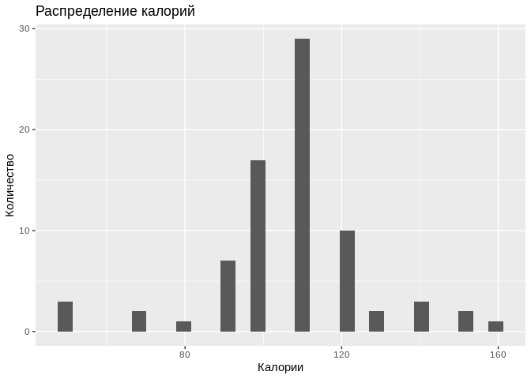

```r
qplot(data = df, x = calories) +
  labs(x = 'Калории', y = 'Количество', title = 'Распределение калорий')
```

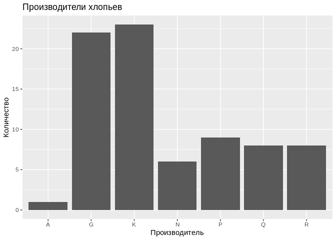

```r
qplot(data = df, x = mfr) +
  labs(x = 'Производитель', y = 'Количество', title = 'Производители хлопьев')
```

5. С помощью той же команды `qplot` постройте диаграмму рассеяния для переменных `carbo` (по оси абсцисс) и `fiber` (по оси ординат). Не забудьте про название графика и осей!

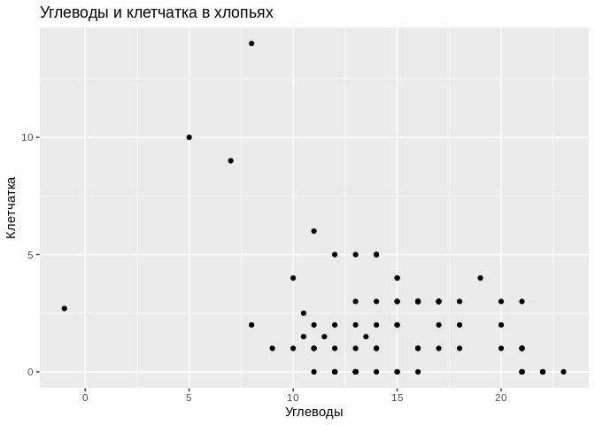

```r
qplot(data = df, x = carbo, y = fiber) +
  labs(x = 'Углеводы', y = 'Клетчатка', title = 'Углеводы и клетчатка в хлопьях')
```

6. Выберите из данных те наблюдения, в которых сахара (`sugars`) в проции больше, чем 10 г, а белков (`protein`) — меньше, чем в средней порции. Cохраните их под названием `df_sub`. Посмотрите на описательные статистики.

```r
df_sub <- filter(df, sugars > 10, protein < mean(protein))
skim(df_sub)
```

```
## Skim summary statistics
##  n obs: 14
##  n variables: 16
##
## Variable type: character
##  variable missing complete  n min max empty n_unique
##       mfr       0       14 14   1   1     0        4
##      name       0       14 14   4  16     0       14
##      type       0       14 14   1   1     0        1
##
## Variable type: integer
##  variable missing complete  n   mean    sd  p0    p25 p50    p75 p100
##  calories       0       14 14 110.71  4.75 100 110    110 110     120
##       fat       0       14 14   0.79  0.7    0   0      1   1       2
##    potass       0       14 14  37.5  13.41  20  26.25  35  43.75   65
##   protein       0       14 14   1.36  0.5    1   1      1   2       2
##     shelf       0       14 14   1.79  0.43   1   2      2   2       2
##    sodium       0       14 14 149.29 54.41  45 125    160 180     220
##    sugars       0       14 14  12.57  1.34  11  12     12  13      15
##  vitamins       0       14 14  25     0     25  25     25  25      25
##      hist
##  ▁▁▁▇▁▁▁▂
##  ▆▁▁▇▁▁▁▂
##  ▇▃▃▃▂▁▃▂
##  ▇▁▁▁▁▁▁▅
##  ▂▁▁▁▁▁▁▇
##  ▂▂▂▃▃▁▇▆
##  ▅▇▁▅▁▂▁▃
##  ▁▁▁▇▁▁▁▁
##
## Variable type: numeric
##  variable missing complete  n  mean   sd    p0   p25   p50   p75  p100
##     carbo       0       14 14 12.07 1.33  9    11.25 12    13    14
##      cups       0       14 14  0.94 0.16  0.75  0.78  1     1     1.33
##     fiber       0       14 14  0.43 0.51  0     0     0     1     1
##    rating       0       14 14 28.24 5.39 18.04 23.74 28.38 32.01 35.78
##    weight       0       14 14  1    0     1     1     1     1     1
##      hist
##  ▂▁▁▅▇▁▅▃
##  ▃▁▁▇▁▁▁▁
##  ▇▁▁▁▁▁▁▆
##  ▂▅▂▂▇▂▇▅
##  ▁▁▁▇▁▁▁▁
```

- Сколько в среднем клетчатки в отобранных данных? *0.43*
7. Добавьте в исходные данные `df` столбец `weight_g` с весом пачки хлопьев в граммах. Вам понадобится функция `mutate`. В одной унции приблизительно 28 грамм :)

```r
df <- mutate(df, weight_g = weight * 28)
skim(df)
```

```
## Skim summary statistics
##  n obs: 77
##  n variables: 17
##
## Variable type: character
##  variable missing complete  n min max empty n_unique
##       mfr       0       77 77   1   1     0        7
##      name       0       77 77   3  38     0       77
##      type       0       77 77   1   1     0        2
##
## Variable type: integer
##  variable missing complete  n   mean    sd p0 p25 p50 p75 p100     hist
##  calories       0       77 77 106.88 19.48 50 100 110 110  160 ▁▁▂▅▇▃▁▁
##       fat       0       77 77   1.01  1.01  0   0   1   2    5 ▇▇▁▃▁▁▁▁
##    potass       0       77 77  96.08 71.29 -1  40  90 120  330 ▇▅▇▂▂▁▁▁
##   protein       0       77 77   2.55  1.09  1   2   3   3    6 ▃▇▁▇▂▁▁▁
##     shelf       0       77 77   2.21  0.83  1   1   2   3    3 ▅▁▁▅▁▁▁▇
##    sodium       0       77 77 159.68 83.83  0 130 180 210  320 ▅▂▁▆▇▅▂▂
##    sugars       0       77 77   6.92  4.44 -1   3   7  11   15 ▅▇▃▆▅▅▆▂
##  vitamins       0       77 77  28.25 22.34  0  25  25  25  100 ▁▇▁▁▁▁▁▁
##
## Variable type: numeric
##  variable missing complete  n  mean    sd    p0   p25   p50   p75 p100
##     carbo       0       77 77 14.6   4.28 -1    12    14    17    23
##      cups       0       77 77  0.82  0.23  0.25  0.67  0.75  1     1.5
##     fiber       0       77 77  2.15  2.38  0     1     2     3    14
##    rating       0       77 77 42.67 14.05 18.04 33.17 40.4  50.83 93.7
##    weight       0       77 77  1.03  0.15  0.5   1     1     1     1.5
##  weight_g       0       77 77 28.83  4.21 14    28    28    28    42
##      hist
##  ▁▁▁▃▇▇▂▃
##  ▁▂▃▅▇▁▁▁
##  ▇▆▂▁▁▁▁▁
##  ▂▇▇▅▂▂▁▁
##  ▁▁▁▇▁▁▁▁
##  ▁▁▁▇▁▁▁▁
```

Какой средний вес порции хлопьев в граммах? *28.83*

8. Отсортируйте исходные данные `df` по рейтингу покупателей с помощью функции `arrange`, сохраните результат в переменной `sorted` и посмотрите на её содержимое.

```r
sorted <- arrange(df, rating)
sorted
```

```
##                                      name mfr type calories protein fat
## 1                            Cap'n'Crunch   Q    C      120       1   2
## 2                   Cinnamon Toast Crunch   G    C      120       1   3
## 3                        Honey Graham Ohs   Q    C      120       1   2
## 4                           Count Chocula   G    C      110       1   1
## 5                             Cocoa Puffs   G    C      110       1   1
## 6                          Golden Grahams   G    C      110       1   1
## 7                            Lucky Charms   G    C      110       2   1
## 8                                    Trix   G    C      110       1   1
## 9                          Fruity Pebbles   P    C      110       1   1
## 10                      Total Raisin Bran   G    C      140       3   1
## 11                             Honey-comb   P    C      110       1   0
## 12                Apple Cinnamon Cheerios   G    C      110       2   2
## 13                       Nut&Honey Crunch   K    C      120       2   1
## 14                   Mueslix Crispy Blend   K    C      160       3   2
```

[output cut: 219 more lines]

- Какова самая низкая оценка покупателей? Самая высокая? *18.04*, *93.7*
9. Экспортируйте отсортированные данные `sorted` в файл формата `xlsx` с названием `cereal_sorted.xlsx`.

```r
export(sorted, 'cereal_sorted.xlsx')
```